# Vietnam Draft Lottery : Replication and Outcome-Weight Diagnostics

Kappa estimators, Double ML, learner sensitivity, and exact weight checks

Alexander Unger

08 August 2026

# Setup

## Packages & Functions

```r
library(haven)
library(AER)
library(sandwich)
library(lmtest)
library(knitr)
library(kableExtra)
library(OutcomeWeights)
library(cobalt)
library(viridis)
library(gridExtra)
library(ggplot2)
library(DoubleML)
library(mlr3verse)
lgr::get_logger("mlr3")$set_threshold("warn")

source(file.path("..", "functions_all.R"))
```

## Data & Design

**Setting.** Angrist (1990) SIPP 1984 subsample (N = 3,027 white men, born 1950–53). Instrument Z = `rsncode` (draft-eligibility indicator). Treatment D = `nvstat` (Vietnam-era veteran status). Outcome: log wages in two units (`lwage = log(kwage)` dollars; `lwage_cnt = log(100·kwage)` cents). Variable definitions follow the SUW Stata replication exactly: `age = age_5`, with three covariate specifications: **Linear** (`age`), **Cubic** (`age, age², age³`), and **Saturated** (`i.age` = age dummies).

```r
sipp_path <- "sipp.dta"
stopifnot(file.exists(sipp_path))
sipp <- read_dta(sipp_path)

sipp_clean <- sipp[sipp$rsncode != 999 &
                     !is.na(sipp$educ) &
                     !is.na(sipp$kwage), ]

sipp_clean$age     <- sipp_clean$age_5
sipp_clean$age2    <- sipp_clean$age_5^2
sipp_clean$age3    <- sipp_clean$age_5^3
sipp_clean$age_fac <- factor(sipp_clean$age_5)

sipp_clean$lwage     <- log(sipp_clean$kwage)
sipp_clean$lwage_cnt <- log(100 * sipp_clean$kwage)

# Core vectors
Y_cnt <- sipp_clean$lwage_cnt
Y_dol <- sipp_clean$lwage
Z     <- as.integer(sipp_clean$rsncode)
D     <- as.integer(sipp_clean$nvstat)

stopifnot(nrow(sipp_clean) == 3027L)
```

```r
# the design matrices contain an intercept
X_lin <- model.matrix(~ age,                data = sipp_clean)
X_cub <- model.matrix(~ age + age2 + age3,  data = sipp_clean)
X_sat <- model.matrix(~ age_fac,            data = sipp_clean)

X_lin_df <- data.frame(age = sipp_clean$age)
X_cub_df <- data.frame(age = sipp_clean$age, age2 = sipp_clean$age2, age3 = sipp_clean$age3)
X_sat_df <- data.frame(age_fac = sipp_clean$age_fac)

X_dml_cub      <- make_X(~ 0 + age + I(age^2) + I(age^3), data = sipp_clean)
X_dml_sat_full <- make_X(~ 0 + age_fac, data = sipp_clean)
X_dml_sat      <- X_dml_sat_full[, -1, drop = FALSE]

stopifnot(nrow(X_dml_cub) == nrow(sipp_clean),
          nrow(X_dml_sat) == nrow(sipp_clean))
```

# 0. Empirical Design Audit

Sample and unconditional treatment uptake

| N | Pr(Z=1) | Pr(D=1) | Pr(D=1 \| Z=0) | Pr(D=1 \| Z=1) |
| --- | --- | --- | --- | --- |
| 3027 | 0.4556 | 0.3284 | 0.2652 | 0.4039 |

Age-adjusted first-stage strength and logit-MLE instrument overlap

| Specification | Adjusted first stage | HC1 SE | Robust t² | Min p̂_MLE(X) | Max p̂_MLE(X) |
| --- | --- | --- | --- | --- | --- |
| Linear age | 0.0949 | 0.0173 | 30.0763 | 0.2810 | 0.6341 |
| Cubic age | 0.0882 | 0.0172 | 26.2639 | 0.1373 | 0.5501 |
| Saturated age | 0.0899 | 0.0173 | 27.1590 | 0.2093 | 0.5671 |

Note:  
Instrument propensities are fitted by logit maximum likelihood. Robust t² is the squared HC1 t-statistic for draft eligibility.

# 1. Reproduction : SUW Table 2

**Layout.** One treatment (veteran status), three age specifications, and two outcome units (cents / dollars). Columns are specification × unit.

**Notation.** `cb` and `ml` denote CBPS and logit-MLE instrument propensities.

```r
run_viet_column <- function(Y, X_kappa, X_df) {
  list(
    tsls  = run_2sls(Y, D, Z, X_df, endog_name = "nvstat"),
    kappa = kappa_analytic_se_all(Y, Z, D, X_kappa)
  )
}

col_lin_cnt <- run_viet_column(Y_cnt, X_lin, X_lin_df)
col_lin_dol <- run_viet_column(Y_dol, X_lin, X_lin_df)
col_cub_cnt <- run_viet_column(Y_cnt, X_cub, X_cub_df)
col_cub_dol <- run_viet_column(Y_dol, X_cub, X_cub_df)
col_sat_cnt <- run_viet_column(Y_cnt, X_sat, X_sat_df)
col_sat_dol <- run_viet_column(Y_dol, X_sat, X_sat_df)
```

## Results

```r
build_spec_table(col_lin_cnt, col_lin_dol, col_cub_cnt, col_cub_dol, col_sat_cnt, col_sat_dol) %>%
  kbl(escape = FALSE, align = c("l","c","c","c","c","c","c"),
      caption = "SUW Table 2 : Treatment: Vietnam veteran status (nvstat). Effect of military service on log wages.") %>%
  kable_styling(bootstrap_options = c("striped","hover","condensed"),
                full_width = TRUE, font_size = 12.5) %>%
  add_header_above(c(" " = 1, "Linear age" = 2, "Cubic age" = 2, "Saturated age" = 2)) %>%
  pack_rows("Panel A: 2SLS (HC1-robust)",            1, 1) %>%
  pack_rows("Panel B: Normalized kappa estimators",  2, 4) %>%
  pack_rows("Panel C: Unnormalized kappa estimators",5, 7) %>%
  row_spec(2:4, background = "#eef6ff") %>%
  row_spec(5:7, background = "#fffbf0") %>%
  footnote(general = paste(
    "Each cell reports the estimate with its analytical or HC1-robust standard error below.",
    "Blue = normalized (translation invariant), orange = unnormalized.",
    "age = age_5, following the SUW replication.",
    "* Statistically significant at the 10% level, ** at the 5% level, *** at the 1% level."
  ))
```

SUW Table 2 : Treatment: Vietnam veteran status (nvstat). Effect of military service on log wages.

| Estimator | Linear age Linear / cents | Linear age Linear / dollars | Cubic age Cubic / cents | Cubic age Cubic / dollars | Saturated age Saturated / cents | Saturated age Saturated / dollars |
| --- | --- | --- | --- | --- | --- | --- |
| **Panel A: 2SLS (HC1-robust)** |  |  |  |  |  |  |
| 2SLS | 0.233 (0.212) | 0.233 (0.212) | 0.227 (0.229) | 0.227 (0.229) | 0.254 (0.227) | 0.254 (0.227) |
| **Panel B: Normalized kappa estimators** |  |  |  |  |  |  |
| τ_cb_u | 0.229 (0.213) | 0.229 (0.213) | 0.210 (0.233) | 0.210 (0.233) | 0.241 (0.229) | 0.241 (0.229) |
| τ_ml_u | 0.234 (0.211) | 0.234 (0.211) | 0.202 (0.235) | 0.202 (0.235) | 0.241 (0.229) | 0.241 (0.229) |
| τ_ml_a10 | 0.227 (0.204) | 0.227 (0.204) | 0.204 (0.239) | 0.204 (0.239) | 0.241 (0.229) | 0.241 (0.229) |
| **Panel C: Unnormalized kappa estimators** |  |  |  |  |  |  |
| τ_ml_a | -0.429* (0.258) | 0.015 (0.207) | 0.537* (0.322) | 0.314 (0.252) | 0.241 (0.229) | 0.241 (0.229) |
| τ_ml_t | -0.455 (0.279) | 0.016 (0.219) | 0.515* (0.301) | 0.302 (0.240) | 0.241 (0.229) | 0.241 (0.229) |
| τ_ml_a0 | -0.413* (0.246) | 0.014 (0.199) | 0.540* (0.326) | 0.317 (0.255) | 0.241 (0.229) | 0.241 (0.229) |

Note:  
Each cell reports the estimate with its analytical or HC1-robust standard error below. Blue = normalized (translation invariant), orange = unnormalized. age = age_5, following the SUW replication. * Statistically significant at the 10% level, ** at the 5% level, *** at the 1% level.

# 2. Double ML : PLR-IV & Wald-AIPW (honest forest, tuned vs. untuned)

**Setting.** DML uses `dml_with_smoother()` with five-fold cross-fitting on the **cubic-age** and **saturated-age** specifications. For each specification, the same call jointly returns PLR-IV and Wald-AIPW. Untuned honest forest (`tune.parameters = "none"`) and a tuned honest forest (`tune.parameters = "all"`). The latter invokes GRF’s automatic, out-of-bag-loss-based tuning; it is distinct from the learner comparison in Section 3. `set.seed(42)` is reset before every fit so that the four calls begin from the same random-number state, although tuning itself consumes additional random draws.

```r
set.seed(42); dml_cub_untuned <- dml_with_smoother(
  Y_dol, D, X_dml_cub, Z, n_cf_folds = 5, tune.parameters = "none")
set.seed(42); dml_cub_tuned <- dml_with_smoother(
  Y_dol, D, X_dml_cub, Z, n_cf_folds = 5, tune.parameters = "all")


set.seed(42); dml_sat_untuned <- dml_with_smoother(
  Y_dol, D, X_dml_sat, Z, n_cf_folds = 5, tune.parameters = "none")
set.seed(42); dml_sat_tuned <- dml_with_smoother(
  Y_dol, D, X_dml_sat, Z, n_cf_folds = 5, tune.parameters = "all")

res_cub_untuned <- summary(dml_cub_untuned)
res_cub_tuned   <- summary(dml_cub_tuned)
res_sat_untuned <- summary(dml_sat_untuned)
res_sat_tuned   <- summary(dml_sat_tuned)

extract_w <- function(dml_obj) {
  om <- get_outcome_weights(dml_obj)
  check_omega_rows(om)
  list(plriv    = as.vector(om$omega["PLR-IV",    ]),
       waldaipw = as.vector(om$omega["Wald-AIPW", ]))
}
w_cub_untuned <- extract_w(dml_cub_untuned)
w_cub_tuned   <- extract_w(dml_cub_tuned)
w_sat_untuned <- extract_w(dml_sat_untuned)
w_sat_tuned   <- extract_w(dml_sat_tuned)
```

## Estimates

### Cubic age

```r
show_dml_cell(res_cub_untuned, w_cub_untuned, Y_dol,
              "Cubic age : untuned honest forest (tune.parameters = \"none\")")
```

Cubic age : untuned honest forest (tune.parameters = “none”)

| Estimator | Estimate | SE | t | p | ω′Y reproduces τ̂ |
| --- | --- | --- | --- | --- | --- |
| PLR-IV | 0.2375 | 0.2278 | 1.0423 | 0.2974 | TRUE |
| Wald-AIPW | 0.2326 | 0.2352 | 0.9889 | 0.3228 | TRUE |

Note:  
Estimator-specific numerical reproduction uses the all.equal() criterion with R’s default tolerance.

```r
show_dml_cell(res_cub_tuned, w_cub_tuned, Y_dol,
              "Cubic age : tuned honest forest (tune.parameters = \"all\")")
```

Cubic age : tuned honest forest (tune.parameters = “all”)

| Estimator | Estimate | SE | t | p | ω′Y reproduces τ̂ |
| --- | --- | --- | --- | --- | --- |
| PLR-IV | 0.2429 | 0.2283 | 1.0641 | 0.2874 | TRUE |
| Wald-AIPW | 0.2291 | 0.2311 | 0.9914 | 0.3216 | TRUE |

Note:  
Estimator-specific numerical reproduction uses the all.equal() criterion with R’s default tolerance.

### Saturated age

```r
show_dml_cell(res_sat_untuned, w_sat_untuned, Y_dol,
              "Saturated age : untuned honest forest (tune.parameters = \"none\")")
```

Saturated age : untuned honest forest (tune.parameters = “none”)

| Estimator | Estimate | SE | t | p | ω′Y reproduces τ̂ |
| --- | --- | --- | --- | --- | --- |
| PLR-IV | 0.2402 | 0.2277 | 1.0548 | 0.2916 | TRUE |
| Wald-AIPW | 0.2344 | 0.2339 | 1.0024 | 0.3162 | TRUE |

Note:  
Estimator-specific numerical reproduction uses the all.equal() criterion with R’s default tolerance.

```r
show_dml_cell(res_sat_tuned, w_sat_tuned, Y_dol,
              "Saturated age : tuned honest forest (tune.parameters = \"all\")")
```

Saturated age : tuned honest forest (tune.parameters = “all”)

| Estimator | Estimate | SE | t | p | ω′Y reproduces τ̂ |
| --- | --- | --- | --- | --- | --- |
| PLR-IV | 0.2416 | 0.2276 | 1.0612 | 0.2887 | TRUE |
| Wald-AIPW | 0.2443 | 0.2333 | 1.0471 | 0.2952 | TRUE |

Note:  
Estimator-specific numerical reproduction uses the all.equal() criterion with R’s default tolerance.

## DML vs. Kappa — Point Estimates

```r
kappa_cub <- kappa_analytic_se_all(Y_dol, Z, D, X_cub)
kappa_sat <- kappa_analytic_se_all(Y_dol, Z, D, X_sat)

cell <- function(coef, se) {
  if (is.na(coef)) return("—")
  if (is.na(se) || !is.finite(se) || se <= 0) return(sprintf("%.3f (NA)", coef))
  sprintf("%.3f%s (%.3f)", coef, sig_stars(coef, se), se)
}

dml_cell <- function(res, est) {
  coef_val <- get_estimate(res, est)
  se_val   <- if ("SE" %in% colnames(res)) as.numeric(res[est, "SE"])
              else if ("Std. Error" %in% colnames(res)) as.numeric(res[est, "Std. Error"])
              else NA_real_
  cell(coef_val, se_val)
}

dml_rows <- rbind(
  data.frame(Estimator = "PLR-IV (untuned forest)",
             `Cubic age`     = dml_cell(res_cub_untuned, "PLR-IV"),
             `Saturated age` = dml_cell(res_sat_untuned, "PLR-IV"),
             check.names = FALSE, stringsAsFactors = FALSE),
  data.frame(Estimator = "Wald-AIPW (untuned forest)",
             `Cubic age`     = dml_cell(res_cub_untuned, "Wald-AIPW"),
             `Saturated age` = dml_cell(res_sat_untuned, "Wald-AIPW"),
             check.names = FALSE, stringsAsFactors = FALSE),
  data.frame(Estimator = "PLR-IV (tuned forest)",
             `Cubic age`     = dml_cell(res_cub_tuned, "PLR-IV"),
             `Saturated age` = dml_cell(res_sat_tuned, "PLR-IV"),
             check.names = FALSE, stringsAsFactors = FALSE),
  data.frame(Estimator = "Wald-AIPW (tuned forest)",
             `Cubic age`     = dml_cell(res_cub_tuned, "Wald-AIPW"),
             `Saturated age` = dml_cell(res_sat_tuned, "Wald-AIPW"),
             check.names = FALSE, stringsAsFactors = FALSE)
)

ests   <- c("tau_cb_u","tau_ml_u","tau_ml_a10","tau_ml_a","tau_ml_t","tau_ml_a0")
labels <- c("τ_cb_u","τ_ml_u","τ_ml_a10","τ_ml_a","τ_ml_t","τ_ml_a0")
kappa_rows <- do.call(rbind, lapply(seq_along(ests), function(i) {
  e <- ests[i]
  data.frame(
    Estimator = labels[i],
    `Cubic age`     = cell(kappa_cub$estimates[e], kappa_cub$se[e]),
    `Saturated age` = cell(kappa_sat$estimates[e], kappa_sat$se[e]),
    check.names = FALSE, stringsAsFactors = FALSE
  )
}))

rbind(dml_rows, kappa_rows) %>%
  kbl(align = c("l","c","c"),
      caption = "DML vs. Kappa — Point Estimates (SE), Y = log wages (dollars)") %>%
  kable_styling(bootstrap_options = c("striped","hover","condensed"),
                full_width = TRUE, font_size = 13) %>%
  pack_rows("Double ML — honest forest", 1, 4) %>%
  pack_rows("Kappa — normalized", 5, 7) %>%
  pack_rows("Kappa — unnormalized", 8, 10) %>%
  row_spec(1:4, background = "#eef6ff") %>%
  row_spec(8:10, background = "#fffbf0") %>%
  footnote(general = paste(
    "Each cell reports estimate (SE). Blue = DML; orange = unnormalized kappa.",
    "* Statistically significant at the 10% level, ** at the 5% level, *** at the 1% level."
  ))
```

DML vs. Kappa — Point Estimates (SE), Y = log wages (dollars)

| Estimator | Cubic age | Saturated age |
| --- | --- | --- |
| **Double ML — honest forest** |  |  |
| PLR-IV (untuned forest) | 0.237 (0.228) | 0.240 (0.228) |
| Wald-AIPW (untuned forest) | 0.233 (0.235) | 0.234 (0.234) |
| PLR-IV (tuned forest) | 0.243 (0.228) | 0.242 (0.228) |
| Wald-AIPW (tuned forest) | 0.229 (0.231) | 0.244 (0.233) |
| **Kappa — normalized** |  |  |
| τ_cb_u | 0.210 (0.233) | 0.241 (0.229) |
| τ_ml_u | 0.202 (0.235) | 0.241 (0.229) |
| τ_ml_a10 | 0.204 (0.239) | 0.241 (0.229) |
| **Kappa — unnormalized** |  |  |
| τ_ml_a | 0.314 (0.252) | 0.241 (0.229) |
| τ_ml_t | 0.302 (0.240) | 0.241 (0.229) |
| τ_ml_a0 | 0.317 (0.255) | 0.241 (0.229) |

Note:  
Each cell reports estimate (SE). Blue = DML; orange = unnormalized kappa. * Statistically significant at the 10% level, ** at the 5% level, *** at the 1% level.

# 3. Learner Comparison — PLR-IV and Wald-AIPW

**Purpose.** This section holds the five-fold DoubleML procedure fixed and varies the nuisance learners. Parametric linear/logistic models, Ranger, and XGBoost. Each learner family is used for both estimators. PLR-IV is implemented with `DoubleMLPLIV`, Wald-AIPW/LATE is implemented with `DoubleMLIIVM`. All models use the same cubic-age and saturated-age designs defined above. Linear and Ranger are fitted in this notebook. XGBoost is imported from `vietnam_xgb_tuning_export.rds` and `vietnam_xgb_pliv_tuning_export.rds`, which preserve both the fixed untuned baseline and the `tune_on_folds = TRUE` estimator without rerunning expensive nested tuning here.

**Terminology.** “Linear learner” refers to the nuisance-model class. OLS for PLR-IV and OLS/logit for Wald-AIPW. The learner comparison uses either the cubic-age feature matrix or the saturated-age feature matrix throughout.

```r
make_dml_data <- function(X_dml) {
  df <- as.data.frame(X_dml)
  df$y <- as.numeric(Y_dol)
  df$d <- as.numeric(D)
  df$z <- as.numeric(Z)
  DoubleMLData$new(data = df, y_col = "y", d_cols = "d", z_cols = "z",
                   x_cols = colnames(X_dml))
}

dat_cub <- make_dml_data(X_dml_cub)
dat_sat <- make_dml_data(X_dml_sat)
```

## Estimates

### OLS / Logistic nuisance learners

```r
lm_iivm_cub <- fit_iivm(dat_cub, ml_lm_iivm(), Y_dol)
lm_iivm_sat <- fit_iivm(dat_sat, ml_lm_iivm(), Y_dol)
lm_pliv_cub <- fit_pliv(dat_cub, ml_lm_pliv(), Y_dol)
lm_pliv_sat <- fit_pliv(dat_sat, ml_lm_pliv(), Y_dol)

learner_pair_table(lm_pliv_cub, lm_pliv_sat, lm_iivm_cub, lm_iivm_sat,
                   "Parametric learners : Linear PLR-IV and Linear/Logistic Wald-AIPW")
```

Parametric learners : Linear PLR-IV and Linear/Logistic Wald-AIPW

| Estimator | Specification | Estimate | SE | ω′Y reproduces τ̂ |
| --- | --- | --- | --- | --- |
| PLR-IV | Cubic age | 0.2388 | 0.2307 | FALSE |
| PLR-IV | Saturated age | 0.2701 | 0.2303 | TRUE |
| Wald-AIPW / LATE | Cubic age | 0.2178 | 0.2326 | TRUE |
| Wald-AIPW / LATE | Saturated age | 0.2468 | 0.2341 | TRUE |

Note:  
Each fitted estimator is checked separately using the all.equal() criterion with R’s default tolerance.

**Cubic OLS PLR-IV.** The `FALSE` is a borderline numerical-conditioning artifact, not evidence against the PLR-IV representation. The reported estimate is 0.2387739352 versus $\omega'Y=0.2387739389$: the relative difference $1.553\times10^{-8}$ lies just above R’s default tolerance $1.490\times10^{-8}$.

### Ranger

```r
rf_iivm_cub <- fit_iivm(dat_cub, ml_rf_iivm(), Y_dol)
rf_iivm_sat <- fit_iivm(dat_sat, ml_rf_iivm(), Y_dol)
rf_pliv_cub <- fit_pliv(dat_cub, ml_rf_pliv(), Y_dol)
rf_pliv_sat <- fit_pliv(dat_sat, ml_rf_pliv(), Y_dol)

learner_pair_table(rf_pliv_cub, rf_pliv_sat, rf_iivm_cub, rf_iivm_sat,
                   "Ranger learners : PLR-IV and Wald-AIPW/LATE")
```

Ranger learners : PLR-IV and Wald-AIPW/LATE

| Estimator | Specification | Estimate | SE | ω′Y reproduces τ̂ |
| --- | --- | --- | --- | --- |
| PLR-IV | Cubic age | 0.2697 | 0.2303 | TRUE |
| PLR-IV | Saturated age | 0.2834 | 0.2229 | TRUE |
| Wald-AIPW / LATE | Cubic age | 0.2461 | 0.2344 | TRUE |
| Wald-AIPW / LATE | Saturated age | 0.2610 | 0.2236 | TRUE |

Note:  
Each fitted estimator is checked separately using the all.equal() criterion with R’s default tolerance.

### Imported XGBoost fits

Imported XGBoost estimates: Untuned and fold-specific tuning

| Estimator | Specification | Untuned | Tuned | ω′Y reproduces τ̂ (untuned / tuned) |
| --- | --- | --- | --- | --- |
| PLR-IV | Cubic age | 0.270 (0.230) | 0.265 (0.229) | FALSE / FALSE |
| PLR-IV | Saturated age | 0.270 (0.230) | 0.281 (0.230) | FALSE / FALSE |
| Wald-AIPW / LATE | Cubic age | 0.246 (0.234) | 0.238 (0.228) | FALSE / FALSE |
| Wald-AIPW / LATE | Saturated age | 0.246 (0.234) | 0.253 (0.230) | FALSE / FALSE |

Note:  
Each estimate cell reports estimate (SE). Each fitted estimator is checked separately using the all.equal() criterion with R’s default tolerance.

**Interpretation.** None of the reconstructed XGBoost vectors passes the estimator-specific `all.equal()` reproduction check.

## Comparison Table

```r
ext_cell <- function(coef, se) {
  if (is.na(coef) || !is.finite(coef)) return("—")
  if (is.na(se) || !is.finite(se) || se <= 0) return(sprintf("%.3f (NA)", coef))
  sprintf("%.3f%s (%.3f)", coef, sig_stars(coef, se), se)
}

star_imported_cell <- function(x) {
  if (is.na(x) || identical(x, "—")) return(x)
  match <- regexec(
    "^\\s*([-+]?[0-9]*\\.?[0-9]+)\\s*\\(([-+]?[0-9]*\\.?[0-9]+)\\)\\s*$",
    x
  )
  parts <- regmatches(x, match)[[1]]
  if (length(parts) != 3L) return(x)
  est <- as.numeric(parts[2])
  se  <- as.numeric(parts[3])
  sprintf("%.3f%s (%.3f)", est, sig_stars(est, se), se)
}

learner_row <- function(label, f_cub, f_sat) {
  data.frame(
    Estimator = label,
    `Cubic age`     = ext_cell(safe_coef(f_cub), safe_se(f_cub)),
    `Saturated age` = ext_cell(safe_coef(f_sat), safe_se(f_sat)),
    check.names = FALSE, stringsAsFactors = FALSE
  )
}

kappa_ref_row <- function(label, key) {
  data.frame(
    Estimator = label,
    `Cubic age`     = ext_cell(kappa_cub$estimates[key], kappa_cub$se[key]),
    `Saturated age` = ext_cell(kappa_sat$estimates[key], kappa_sat$se[key]),
    check.names = FALSE, stringsAsFactors = FALSE
  )
}

comparison_rows <- list(
  learner_row("PLR-IV (OLS nuisances)",                  lm_pliv_cub,  lm_pliv_sat),
  learner_row("Wald-AIPW / LATE (OLS/logit nuisances)", lm_iivm_cub, lm_iivm_sat),
  learner_row("PLR-IV (ranger)",                  rf_pliv_cub,  rf_pliv_sat),
  learner_row("Wald-AIPW / LATE (ranger)",       rf_iivm_cub, rf_iivm_sat),
  kappa_ref_row("τ_cb_u (kappa, ref)",  "tau_cb_u"),
  kappa_ref_row("τ_ml_u (kappa, ref)",  "tau_ml_u")
)
xgb_rows <- list(
  data.frame(Estimator="PLR-IV (XGBoost, untuned)",
    `Cubic age`=star_imported_cell(get_xgb_estimate_cell(xgb_pliv_obj,"Cubic age","untuned")),
    `Saturated age`=star_imported_cell(get_xgb_estimate_cell(xgb_pliv_obj,"Saturated age","untuned")),check.names=FALSE),
  data.frame(Estimator="PLR-IV (XGBoost, tune_on_folds=TRUE)",
    `Cubic age`=star_imported_cell(get_xgb_estimate_cell(xgb_pliv_obj,"Cubic age","tuned")),
    `Saturated age`=star_imported_cell(get_xgb_estimate_cell(xgb_pliv_obj,"Saturated age","tuned")),check.names=FALSE),
  data.frame(Estimator="Wald-AIPW / LATE (XGBoost, untuned)",
    `Cubic age`=star_imported_cell(get_xgb_estimate_cell(xgb_wald_obj,"Cubic age","untuned")),
    `Saturated age`=star_imported_cell(get_xgb_estimate_cell(xgb_wald_obj,"Saturated age","untuned")),check.names=FALSE),
  data.frame(Estimator="Wald-AIPW / LATE (XGBoost, tune_on_folds=TRUE)",
    `Cubic age`=star_imported_cell(get_xgb_estimate_cell(xgb_wald_obj,"Cubic age","tuned")),
    `Saturated age`=star_imported_cell(get_xgb_estimate_cell(xgb_wald_obj,"Saturated age","tuned")),check.names=FALSE)
)
comp_df <- do.call(rbind,c(comparison_rows[1:4],xgb_rows,comparison_rows[5:6]))

comp_df %>%
  kbl(align = c("l","c","c"),
      caption = "PLR-IV and Wald-AIPW Learner Comparison — DoubleML vs. Kappa (Y = log wages, dollars)") %>%
  kable_styling(bootstrap_options = c("striped","hover","condensed"),
                full_width = TRUE, font_size = 13) %>%
  pack_rows("DoubleML learners", 1, 8) %>%
  pack_rows("Kappa reference",   9, 10) %>%
  row_spec(1:8, background = "#eef6ff") %>%
  footnote(general = paste(
    "Each cell reports estimate (SE). Linear denotes the nuisance learner, not the linear-age feature specification.",
    "XGBoost rows import the stored nested-tuning fits; their point estimates are retained although their reconstructed weights fail the reproduction gate."  ))
```

PLR-IV and Wald-AIPW Learner Comparison — DoubleML vs. Kappa (Y = log wages, dollars)

| Estimator | Cubic age | Saturated age |
| --- | --- | --- |
| **DoubleML learners** |  |  |
| PLR-IV (OLS nuisances) | 0.239 (0.231) | 0.270 (0.230) |
| Wald-AIPW / LATE (OLS/logit nuisances) | 0.218 (0.233) | 0.247 (0.234) |
| PLR-IV (ranger) | 0.270 (0.230) | 0.283 (0.223) |
| Wald-AIPW / LATE (ranger) | 0.246 (0.234) | 0.261 (0.224) |
| PLR-IV (XGBoost, untuned) | 0.270 (0.230) | 0.270 (0.230) |
| PLR-IV (XGBoost, tune_on_folds=TRUE) | 0.265 (0.229) | 0.281 (0.230) |
| Wald-AIPW / LATE (XGBoost, untuned) | 0.246 (0.234) | 0.246 (0.234) |
| Wald-AIPW / LATE (XGBoost, tune_on_folds=TRUE) | 0.238 (0.228) | 0.253 (0.230) |
| **Kappa reference** |  |  |
| τ_cb_u (kappa, ref) | 0.210 (0.233) | 0.241 (0.229) |
| τ_ml_u (kappa, ref) | 0.202 (0.235) | 0.241 (0.229) |

Note:  
Each cell reports estimate (SE). Linear denotes the nuisance learner, not the linear-age feature specification. XGBoost rows import the stored nested-tuning fits; their point estimates are retained although their reconstructed weights fail the reproduction gate.

# 4. Weight Diagnostics

## Detailed Outcome-Weight Statistics

### Cubic age

```r
bridge_table(bridge_cells[["Cubic age"]]$w,
             "Detailed outcome-weight statistics: Cubic age")
```

Detailed outcome-weight statistics: Cubic age

| Scope | Knaus summary() statistics Min | Knaus summary() statistics Max | Knaus summary() statistics Neg. share | Knaus summary() statistics ΣTop10% | Knaus summary() statistics Σω | Knaus summary() statistics Σ\|ω\| |
| --- | --- | --- | --- | --- | --- | --- |
| **PLR-IV (tuned forest)** |  |  |  |  |  |  |
| Overall | -0.0100043 | 0.0124943 | 0.5444 | 3.305107 | 0.0000000 | 22.368460 |
| Treated | -0.0099890 | 0.0120863 | 0.4396 | 1.013707 | 0.9942484 | 7.663232 |
| Control | -0.0124943 | 0.0100043 | 0.4043 | 1.825281 | 0.9942484 | 14.705228 |
| **Wald-AIPW (tuned forest)** |  |  |  |  |  |  |
| Overall | -0.0100529 | 0.0176271 | 0.5444 | 3.803619 | 0.0000000 | 22.630869 |
| Treated | -0.0100092 | 0.0158655 | 0.4396 | 1.107367 | 0.9997660 | 7.532967 |
| Control | -0.0176271 | 0.0100529 | 0.4043 | 1.791186 | 0.9997660 | 15.097902 |
| **Wald-AIPW (OLS/logit nuisances)** |  |  |  |  |  |  |
| Overall | -0.0098412 | 0.0269260 | 0.5444 | 3.703946 | 0.0000000 | 23.017141 |
| Treated | -0.0098412 | 0.0263010 | 0.4396 | 1.076075 | 0.9914555 | 7.644959 |
| Control | -0.0269260 | 0.0098412 | 0.4043 | 1.783309 | 0.9914555 | 15.372182 |
| **PLR-IV (ranger)** |  |  |  |  |  |  |
| Overall | -0.0106351 | 0.0135375 | 0.5444 | 3.345716 | 0.0000000 | 22.538121 |
| Treated | -0.0106016 | 0.0123536 | 0.4396 | 1.019653 | 0.9993512 | 7.710686 |
| Control | -0.0135375 | 0.0106351 | 0.4043 | 1.886373 | 0.9993512 | 14.827435 |
| **Wald-AIPW (ranger)** |  |  |  |  |  |  |
| Overall | -0.0107462 | 0.0216468 | 0.5444 | 3.867691 | 0.0000000 | 22.844452 |
| Treated | -0.0107409 | 0.0169352 | 0.4396 | 1.109841 | 0.9989852 | 7.585442 |
| Control | -0.0216468 | 0.0107462 | 0.4043 | 1.835995 | 0.9989852 | 15.259010 |
| **τ_cb_u (kappa)** |  |  |  |  |  |  |
| Overall | -0.0085918 | 0.0253842 | 0.5444 | 3.763057 | 0.0000000 | 23.212958 |
| Treated | -0.0085918 | 0.0253842 | 0.4396 | 1.078845 | 1.0000000 | 7.721620 |
| Control | -0.0253842 | 0.0085918 | 0.4043 | 1.744170 | 1.0000000 | 15.491339 |
| **τ_ml_u (kappa)** |  |  |  |  |  |  |
| Overall | -0.0086113 | 0.0281077 | 0.5444 | 3.846845 | 0.0000000 | 23.439097 |
| Treated | -0.0086113 | 0.0281077 | 0.4396 | 1.091455 | 1.0000000 | 7.781940 |
| Control | -0.0281077 | 0.0086113 | 0.4043 | 1.751632 | 1.0000000 | 15.657157 |
| **τ_ml_a10 (kappa)** |  |  |  |  |  |  |
| Overall | -0.0088730 | 0.0290784 | 0.5444 | 3.939642 | 0.0000000 | 23.827505 |
| Treated | -0.0084618 | 0.0277309 | 0.4396 | 1.076820 | 1.0000000 | 7.664186 |
| Control | -0.0290784 | 0.0088730 | 0.4043 | 1.804859 | 1.0000000 | 16.163320 |
| **τ_ml_a (kappa, unnormalized)** |  |  |  |  |  |  |
| Overall | -0.0088090 | 0.0288688 | 0.5444 | 3.951003 | 0.0482434 | 24.025495 |
| Treated | -0.0088090 | 0.0288688 | 0.4396 | 1.121007 | 1.0410351 | 7.978686 |
| Control | -0.0288688 | 0.0088090 | 0.4043 | 1.791849 | 0.9927916 | 16.046809 |
| **τ_ml_t (kappa, untreated-unnormalized)** |  |  |  |  |  |  |
| Overall | -0.0084618 | 0.0277309 | 0.5444 | 3.795264 | 0.0463418 | 23.078468 |
| Treated | -0.0084618 | 0.0277309 | 0.4396 | 1.076820 | 1.0000000 | 7.664186 |
| Control | -0.0277309 | 0.0084618 | 0.4043 | 1.721219 | 0.9536582 | 15.414283 |
| **τ_ml_a0 (kappa, treated-unnormalized)** |  |  |  |  |  |  |
| Overall | -0.0088730 | 0.0290784 | 0.5444 | 3.979690 | 0.0485937 | 24.199937 |
| Treated | -0.0088730 | 0.0290784 | 0.4396 | 1.129146 | 1.0485937 | 8.036617 |
| Control | -0.0290784 | 0.0088730 | 0.4043 | 1.804859 | 1.0000000 | 16.163320 |

Note:  
Control rows use the sign-flipped −ω convention. Only exact or algebraic representations enter this table.

### Saturated age

```r
bridge_table(bridge_cells[["Saturated age"]]$w,
             "Detailed outcome-weight statistics: Saturated age")
```

Detailed outcome-weight statistics: Saturated age

| Scope | Knaus summary() statistics Min | Knaus summary() statistics Max | Knaus summary() statistics Neg. share | Knaus summary() statistics ΣTop10% | Knaus summary() statistics Σω | Knaus summary() statistics Σ\|ω\| |
| --- | --- | --- | --- | --- | --- | --- |
| **PLR-IV (tuned forest)** |  |  |  |  |  |  |
| Overall | -0.0101283 | 0.0131280 | 0.5444 | 3.314080 | 0.000000 | 22.344091 |
| Treated | -0.0101283 | 0.0122117 | 0.4396 | 1.013914 | 0.999443 | 7.668411 |
| Control | -0.0131280 | 0.0100987 | 0.4043 | 1.852381 | 0.999443 | 14.675680 |
| **Wald-AIPW (tuned forest)** |  |  |  |  |  |  |
| Overall | -0.0102238 | 0.0168664 | 0.5444 | 3.802794 | 0.000000 | 22.727098 |
| Treated | -0.0102238 | 0.0168117 | 0.4396 | 1.103478 | 1.005174 | 7.592771 |
| Control | -0.0168664 | 0.0102133 | 0.4043 | 1.791684 | 1.005174 | 15.134327 |
| **PLR-IV (OLS nuisances)** |  |  |  |  |  |  |
| Overall | -0.0105727 | 0.0134264 | 0.5444 | 3.346545 | 0.000000 | 22.542393 |
| Treated | -0.0105727 | 0.0123712 | 0.4396 | 1.020404 | 1.000000 | 7.713038 |
| Control | -0.0134264 | 0.0105727 | 0.4043 | 1.886760 | 1.000000 | 14.829355 |
| **Wald-AIPW (OLS/logit nuisances)** |  |  |  |  |  |  |
| Overall | -0.0107129 | 0.0217731 | 0.5444 | 3.864244 | 0.000000 | 22.824939 |
| Treated | -0.0107129 | 0.0169064 | 0.4396 | 1.108174 | 1.000000 | 7.578482 |
| Control | -0.0217731 | 0.0107129 | 0.4043 | 1.833351 | 1.000000 | 15.246457 |
| **PLR-IV (ranger)** |  |  |  |  |  |  |
| Overall | -0.0098389 | 0.0118860 | 0.5444 | 3.187438 | 0.000000 | 21.765606 |
| Treated | -0.0098180 | 0.0118635 | 0.4396 | 0.977707 | 1.002930 | 7.437640 |
| Control | -0.0118860 | 0.0098389 | 0.4043 | 1.786843 | 1.002930 | 14.327966 |
| **Wald-AIPW (ranger)** |  |  |  |  |  |  |
| Overall | -0.0097500 | 0.0162113 | 0.5444 | 3.634420 | 0.000000 | 21.923090 |
| Treated | -0.0097239 | 0.0161504 | 0.4396 | 1.064068 | 1.005229 | 7.301045 |
| Control | -0.0162113 | 0.0097500 | 0.4043 | 1.728709 | 1.005229 | 14.622045 |
| **τ_cb_u (kappa)** |  |  |  |  |  |  |
| Overall | -0.0086119 | 0.0178113 | 0.5444 | 3.817075 | 0.000000 | 22.569002 |
| Treated | -0.0086119 | 0.0178113 | 0.4396 | 1.087580 | 1.000000 | 7.504259 |
| Control | -0.0178113 | 0.0086119 | 0.4043 | 1.725194 | 1.000000 | 15.064743 |
| **τ_ml_u (kappa)** |  |  |  |  |  |  |
| Overall | -0.0086119 | 0.0178113 | 0.5444 | 3.817075 | 0.000000 | 22.569002 |
| Treated | -0.0086119 | 0.0178113 | 0.4396 | 1.087580 | 1.000000 | 7.504259 |
| Control | -0.0178113 | 0.0086119 | 0.4043 | 1.725194 | 1.000000 | 15.064743 |
| **τ_ml_a10 (kappa)** |  |  |  |  |  |  |
| Overall | -0.0086119 | 0.0178113 | 0.5444 | 3.817075 | 0.000000 | 22.569002 |
| Treated | -0.0086119 | 0.0178113 | 0.4396 | 1.087580 | 1.000000 | 7.504259 |
| Control | -0.0178113 | 0.0086119 | 0.4043 | 1.725194 | 1.000000 | 15.064743 |
| **τ_ml_a (kappa, unnormalized)** |  |  |  |  |  |  |
| Overall | -0.0086119 | 0.0178113 | 0.5444 | 3.817075 | 0.000000 | 22.569002 |
| Treated | -0.0086119 | 0.0178113 | 0.4396 | 1.087580 | 1.000000 | 7.504259 |
| Control | -0.0178113 | 0.0086119 | 0.4043 | 1.725194 | 1.000000 | 15.064743 |
| **τ_ml_t (kappa, untreated-unnormalized)** |  |  |  |  |  |  |
| Overall | -0.0086119 | 0.0178113 | 0.5444 | 3.817075 | 0.000000 | 22.569002 |
| Treated | -0.0086119 | 0.0178113 | 0.4396 | 1.087580 | 1.000000 | 7.504259 |
| Control | -0.0178113 | 0.0086119 | 0.4043 | 1.725194 | 1.000000 | 15.064743 |
| **τ_ml_a0 (kappa, treated-unnormalized)** |  |  |  |  |  |  |
| Overall | -0.0086119 | 0.0178113 | 0.5444 | 3.817075 | 0.000000 | 22.569002 |
| Treated | -0.0086119 | 0.0178113 | 0.4396 | 1.087580 | 1.000000 | 7.504259 |
| Control | -0.0178113 | 0.0086119 | 0.4043 | 1.725194 | 1.000000 | 15.064743 |

Note:  
Control rows use the sign-flipped −ω convention. Only exact or algebraic representations enter this table.

## ESS and Sign-Cancellation Extension

**Extension.** Modified ESS is shown separately for treated and control observations, followed by the value relative to each observed arm size. `Opposite-sign mass T/C` is the percentage of absolute mass with the opposite orientation within each arm. It measures sign cancellation rather than the number of negative observations. In an IV design, signs are also shaped by the residualized instrument, so a high value is not by itself evidence of an invalid estimator.

### Cubic age

```r
extension_table(bridge_cells[["Cubic age"]]$w,
                "Modified ESS and sign cancellation: Cubic age")
```

Modified ESS and sign cancellation: Cubic age

| Estimator | ESS mod T/C | ESS mod/N T/C | Opposite-sign mass T/C (%) |
| --- | --- | --- | --- |
| PLR-IV (tuned forest) | 958 / 1872 | 0.963 / 0.921 | 43.5 / 46.6 |
| Wald-AIPW (tuned forest) | 946 / 1850 | 0.952 / 0.910 | 43.4 / 46.7 |
| Wald-AIPW (OLS/logit nuisances) | 950 / 1845 | 0.955 / 0.908 | 43.5 / 46.8 |
| PLR-IV (ranger) | 954 / 1862 | 0.960 / 0.916 | 43.5 / 46.6 |
| Wald-AIPW (ranger) | 942 / 1836 | 0.948 / 0.903 | 43.4 / 46.7 |
| τ_cb_u (kappa) | 952 / 1846 | 0.958 / 0.908 | 43.5 / 46.8 |
| τ_ml_u (kappa) | 949 / 1827 | 0.954 / 0.899 | 43.6 / 46.8 |
| τ_ml_a10 (kappa) | 949 / 1826 | 0.954 / 0.898 | 43.5 / 46.9 |
| τ_ml_a (kappa, unnormalized) | 949 / 1826 | 0.954 / 0.898 | 43.5 / 46.9 |
| τ_ml_t (kappa, untreated-unnormalized) | 949 / 1826 | 0.954 / 0.898 | 43.5 / 46.9 |
| τ_ml_a0 (kappa, treated-unnormalized) | 949 / 1826 | 0.954 / 0.898 | 43.5 / 46.9 |

Note:  
T/C denotes treated / sign-oriented control. Only exact or algebraic representations enter this extension.

### Saturated age

```r
extension_table(bridge_cells[["Saturated age"]]$w,
                "Modified ESS and sign cancellation: Saturated age")
```

Modified ESS and sign cancellation: Saturated age

| Estimator | ESS mod T/C | ESS mod/N T/C | Opposite-sign mass T/C (%) |
| --- | --- | --- | --- |
| PLR-IV (tuned forest) | 955 / 1864 | 0.961 / 0.917 | 43.5 / 46.6 |
| Wald-AIPW (tuned forest) | 945 / 1847 | 0.951 / 0.908 | 43.4 / 46.7 |
| PLR-IV (OLS nuisances) | 954 / 1862 | 0.960 / 0.916 | 43.5 / 46.6 |
| Wald-AIPW (OLS/logit nuisances) | 943 / 1835 | 0.948 / 0.903 | 43.4 / 46.7 |
| PLR-IV (ranger) | 958 / 1879 | 0.964 / 0.924 | 43.3 / 46.5 |
| Wald-AIPW (ranger) | 945 / 1858 | 0.951 / 0.914 | 43.1 / 46.6 |
| τ_cb_u (kappa) | 947 / 1848 | 0.953 / 0.909 | 43.3 / 46.7 |
| τ_ml_u (kappa) | 947 / 1848 | 0.953 / 0.909 | 43.3 / 46.7 |
| τ_ml_a10 (kappa) | 947 / 1848 | 0.953 / 0.909 | 43.3 / 46.7 |
| τ_ml_a (kappa, unnormalized) | 947 / 1848 | 0.953 / 0.909 | 43.3 / 46.7 |
| τ_ml_t (kappa, untreated-unnormalized) | 947 / 1848 | 0.953 / 0.909 | 43.3 / 46.7 |
| τ_ml_a0 (kappa, treated-unnormalized) | 947 / 1848 | 0.953 / 0.909 | 43.3 / 46.7 |

Note:  
T/C denotes treated / sign-oriented control. Only exact or algebraic representations enter this extension.

# 5. Love Plots

**Balance scale.** Each panel reports absolute mean differences only. Continuous covariates are standardized by the pooled unadjusted standard deviation. Starred binary covariates are left on their raw 0/1 scale.

## DML vs. Kappa

### Cubic age (untuned/tuned forests and kappa)

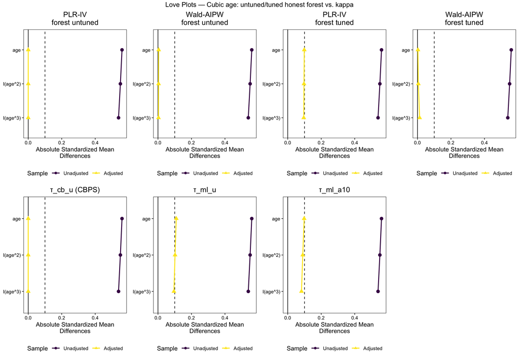

```r
grobs <- Filter(Negate(is.null), list(
  maybe_love("PLR-IV\nforest untuned",    w_cub_untuned$plriv,    D, X_dml_cub),
  maybe_love("Wald-AIPW\nforest untuned", w_cub_untuned$waldaipw, D, X_dml_cub),
  maybe_love("PLR-IV\nforest tuned",      w_cub_tuned$plriv,      D, X_dml_cub),
  maybe_love("Wald-AIPW\nforest tuned",   w_cub_tuned$waldaipw,   D, X_dml_cub),
  maybe_love("τ_cb_u (CBPS)",    kw_cub$tau_cb_u,   D, X_dml_cub),
  maybe_love("τ_ml_u",           kw_cub$tau_ml_u,   D, X_dml_cub),
  maybe_love("τ_ml_a10",         kw_cub$tau_ml_a10, D, X_dml_cub)
))
grid.arrange(grobs = grobs, nrow = 2,
             top = "Love Plots — Cubic age: untuned/tuned honest forest vs. kappa")
```

### Saturated age (untuned/tuned forests and kappa)

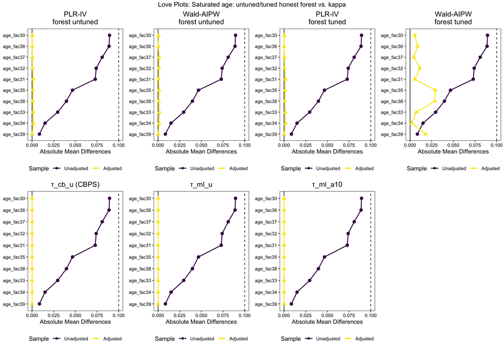

```r
grobs <- Filter(Negate(is.null), list(
  maybe_love("PLR-IV\nforest untuned",    w_sat_untuned$plriv,    D, X_dml_sat),
  maybe_love("Wald-AIPW\nforest untuned", w_sat_untuned$waldaipw, D, X_dml_sat),
  maybe_love("PLR-IV\nforest tuned",      w_sat_tuned$plriv,      D, X_dml_sat),
  maybe_love("Wald-AIPW\nforest tuned",   w_sat_tuned$waldaipw,   D, X_dml_sat),
  maybe_love("τ_cb_u (CBPS)",    kw_sat$tau_cb_u,   D, X_dml_sat),
  maybe_love("τ_ml_u",           kw_sat$tau_ml_u,   D, X_dml_sat),
  maybe_love("τ_ml_a10",         kw_sat$tau_ml_a10, D, X_dml_sat)
))
grid.arrange(grobs = grobs, nrow = 2,
             top = "Love Plots: Saturated age: untuned/tuned honest forest vs. kappa")
```

## Learners vs. Kappa

### Cubic age (PLR-IV and Wald-AIPW by learner)

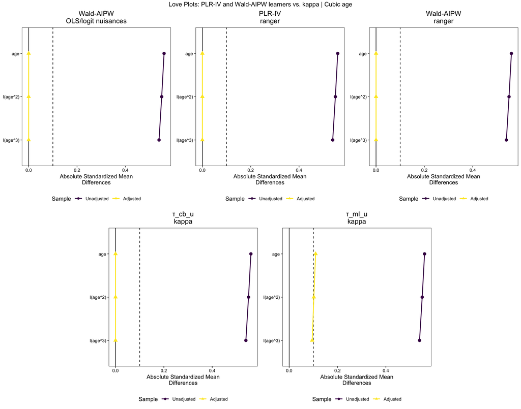

```r
grobs <- Filter(Negate(is.null), list(
  maybe_love("PLR-IV\nOLS nuisances", lm_pliv_cub$w, D, X_dml_cub, lm_pliv_cub$ok),
  maybe_love("Wald-AIPW\nOLS/logit nuisances", lm_iivm_cub$w, D, X_dml_cub, lm_iivm_cub$ok),
  maybe_love("PLR-IV\nranger",       rf_pliv_cub$w,   D, X_dml_cub, rf_pliv_cub$ok),
  maybe_love("Wald-AIPW\nranger",    rf_iivm_cub$w,   D, X_dml_cub, rf_iivm_cub$ok),
  maybe_love("τ_cb_u\nkappa",        kw_cub$tau_cb_u, D, X_dml_cub),
  maybe_love("τ_ml_u\nkappa",        kw_cub$tau_ml_u, D, X_dml_cub)
))
love_layout_cub <- rbind(
  c(1, 1, 2, 2, 3, 3),
  c(NA, 4, 4, 5, 5, NA)
)
grid.arrange(grobs = grobs, layout_matrix = love_layout_cub,
             top = "Love Plots: PLR-IV and Wald-AIPW learners vs. kappa | Cubic age")
```

### Saturated age (PLR-IV and Wald-AIPW by learner)

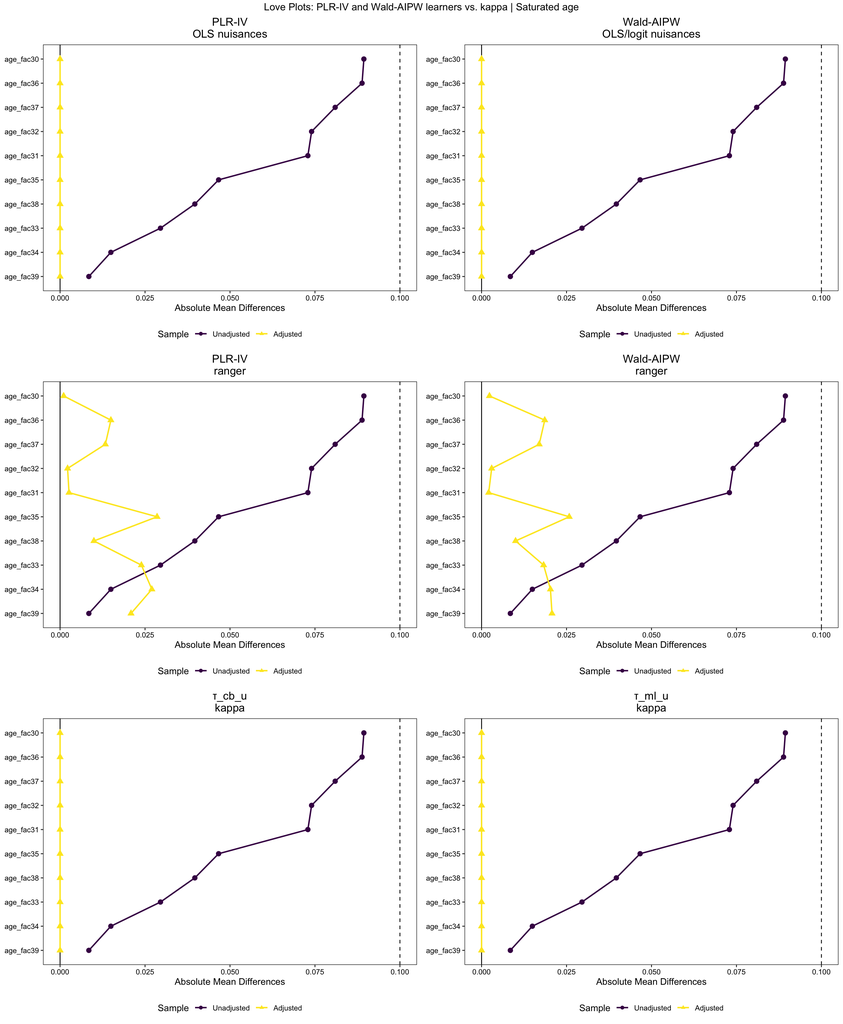

```r
grobs <- Filter(Negate(is.null), list(
  maybe_love("PLR-IV\nOLS nuisances", lm_pliv_sat$w, D, X_dml_sat, lm_pliv_sat$ok),
  maybe_love("Wald-AIPW\nOLS/logit nuisances", lm_iivm_sat$w, D, X_dml_sat, lm_iivm_sat$ok),
  maybe_love("PLR-IV\nranger",       rf_pliv_sat$w,   D, X_dml_sat, rf_pliv_sat$ok),
  maybe_love("Wald-AIPW\nranger",    rf_iivm_sat$w,   D, X_dml_sat, rf_iivm_sat$ok),
  maybe_love("τ_cb_u\nkappa",        kw_sat$tau_cb_u, D, X_dml_sat),
  maybe_love("τ_ml_u\nkappa",        kw_sat$tau_ml_u, D, X_dml_sat)
))
grid.arrange(grobs = grobs, ncol = 2,
             top = "Love Plots: PLR-IV and Wald-AIPW learners vs. kappa | Saturated age")
```